# Final Paper

STOR 320.01 Group 14

April 27, 2026

# DATA

The dataset used is from FiveThirtyEight’s data, a website owned by ABC News that focuses on American economics, opinion polls, and politics, titled Police Killings. The data used in this dataset is collected by the Guardian and the Census’s American Community Survey. The Guardian led a project called “The Counted,” which is the most comprehensive database of fatal police killings in the United States in 2015 and 2016. This project was created due to the United States government’s lack of a complete record of police violence and individuals killed by law enforcement. So, “The Counted” was created in response to the growing debate over the issue of police violence in the United States, especially after highly publicized events such as those involving Michael Brown, Eric Garner, Rekia Boyd, and others. The Guardian used data from police reports, local governments, research organizations, and both nationwide and local open-source reporting projects.

The American Community Survey (ACS) was also utilized in this dataset to provide demographic information to support the Guardian’s data. The ACS is an ongoing U.S. Census Bureau survey collecting a variety of detailed economic, social, and demographic data annually from over 3 million American households. It provides up-to-date, highly detailed data, often down to census tracts (a small subdivision of a county optimally containing 4000 residents used for statistical purposes), that is primarily used to help aid federal funding and governmental decisions. However, it is also often used in sociological research.

Raceethnicity is a categorical variable representing the race or ethnicity of the victim. This variable had 6 factors being “White,” “Black,” “Hispanic/Latino,” “Asian/Pacific Islander,” “Native American,” and “NA” (we grouped all N/A and “Other” instances together). The count and frequency of this raceethnicity can be seen in the figure below. Early on, we mutated the variable armed to Yes or No, where Yes represented if the victim was armed at all, which included being armed with firearms, vehicles, knives, non-lethal firearms, and other weapons. The last categorical variable we used was gender, which represented the gender of the victim. This variable had two levels: Female or Male.

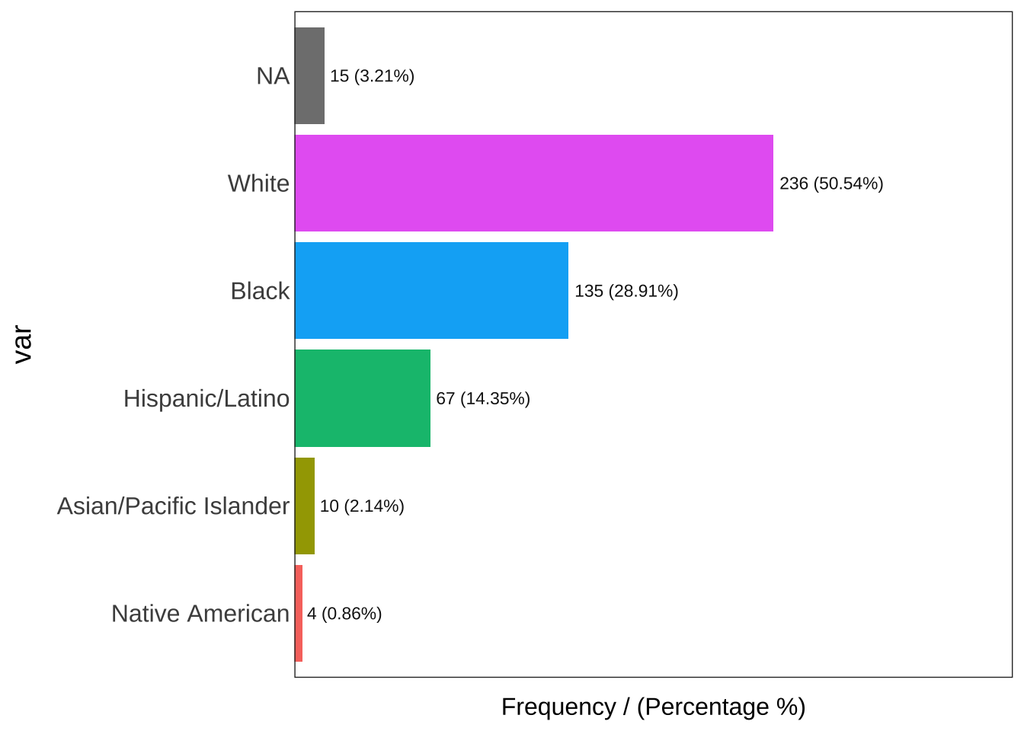

The remaining variables in our analysis were numeric. The variables share_white, share_black, and share_hispanic represent the percentage of each respective racial group within the census tract where the victim was killed. We used the variable h_income to measure income in our analysis. Strictly speaking, h_income tracks the tract-level median household income. To analyze demographic data of the regions where each victim was killed, we used pov, urate, and college. pov measures the official tract-level poverty rate, urate tracks the tract-level unemployment rate, while college represents the share of the population above the age of 25 within the tract that has a Bachelor’s of Arts degree or higher. Lastly, age is provided as an integer to measure the victim’s age at the time of the killing.

Sample of the Dataset (First 10 Observations)

| raceethnicity | armed | share_white | share_black | share_hispanic | h_income | pov | urate | college | age | gender |
| --- | --- | --- | --- | --- | --- | --- | --- | --- | --- | --- |
| Black | No | 60.5 | 30.5 | 5.6 | 51367 | 14.1 | 0.0976864 | 0.1685095 | 16 | Male |
| White | No | 53.8 | 36.2 | 0.5 | 27972 | 28.8 | 0.0657238 | 0.1114024 | 27 | Male |
| White | No | 73.8 | 7.7 | 16.8 | 45365 | 14.6 | 0.1662931 | 0.1473123 | 26 | Male |
| Hispanic/Latino | Yes | 1.2 | 0.6 | 98.8 | 48295 | 11.7 | 0.1248273 | 0.0501329 | 25 | Male |
| White | No | 92.5 | 1.4 | 1.7 | 68785 | 1.9 | 0.0635498 | 0.4039542 | 29 | Male |
| White | No | 7.0 | 7.7 | 79.0 | 20833 | 58.0 | 0.0736515 | 0.1029552 | 29 | Male |
| Hispanic/Latino | Yes | 50.8 | 0.3 | 44.2 | 58068 | 17.2 | 0.1314611 | 0.2038012 | 22 | Male |
| Hispanic/Latino | Yes | 8.6 | 0.2 | 84.1 | 66543 | 12.2 | 0.0943470 | 0.0904376 | 35 | Male |
| White | Yes | 14.6 | 17.7 | 66.3 | 30391 | 37.7 | 0.1408330 | 0.0476013 | 44 | Male |
| White | Yes | 63.6 | 7.7 | 26.5 | 44553 | 18.4 | 0.1741674 | 0.1026915 | 31 | Male |

Notably, our dataset had a few missing values. raceethnicity was the variable with the highest missingness that was used in our analysis, at a missingness value of only 3.21%. No other variable used has a missingness of over 1%, and several had fully complete data. Thus, the issue of missingness only posed a minor issue in our second question, where we remedied this by simply omitting the instances with a missing raceethnicity value.

# RESULTS

### Question 1

In discussions of police killings, whether a victim was armed is often treated as an individual-level factor related to the perceived threat of the encounter. However, this perspective focuses mainly on individual behavior and pays less attention to the broader context in which these events occur. In this project, we ask whether neighborhood level socioeconomic characteristics such as poverty rate, unemployment rate, household income, and college attainment contain any information about whether a victim was armed. This question is of interest because it allows us to examine whether factors beyond the individual level are associated with armed status. If these neighborhood characteristics show any consistent relationship with the outcome, it suggests that the surrounding socioeconomic environment may play some role, even if limited. At the same time, if the relationship turns out to be weak, it would indicate that these variables alone are not sufficient to explain the outcome, and that more detailed individual or situational factors may be needed.

Before fitting any models, we first fit a simple logistic regression on the original data (without any resampling), based on the prior exploratory data analysis, to get a preliminary sense of whether any of the four variables showed a meaningful trend. The plots below show the relationship between each variable and the predicted probability of being armed, with a LOESS (Locally Estimated Scatterplot Smoothing), which is a smoothing method used to visualize the overall trend between two variables. It fits simple regressions within small local neighborhoods of the data and combines them into a smooth curve. We use the smooth curve to highlight the overall direction. Higher poverty rates and higher unemployment rates are associated with a slightly higher predicted probability of being armed, while higher household income and higher college attainment are associated with a slightly lower predicted probability of being armed. The trends are not dramatic, but they are consistent enough in direction that these variables seemed worth exploring further in a more careful modeling setup. Based on these results, we include four factors(poverty rate, college attainment, unemployment rate, and household income) as predictors to jointly model whether the victim is armed.

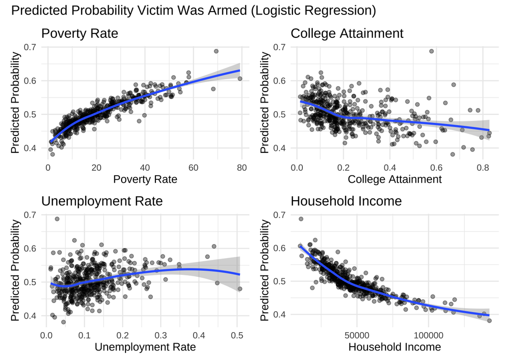

One issue we ran into right away was that the outcome variable was very imbalanced; about 78% of victims were recorded as armed, and only about 22% were not. Training a model on data like this can cause it to just predict “Yes” for almost everything, which is not very useful. To address class imbalance, we used SMOTE (Synthetic Minority Oversampling Technique), a method that generates synthetic samples for the minority class by interpolating between existing observations. This helps balance the dataset and prevents the model from being biased toward the majority class. After applying SMOTE to the training data, we fit two models including a logistic regression and a decision tree, and evaluated their performance on a test set. Importantly, SMOTE was applied only to the training data, while the test set was kept unchanged. This ensures that the test set still reflects the original data distribution and provides a realistic evaluation of model performance.

The logistic regression model performed inadequately. Its AUC came out to 0.539, which is only slightly above 0.5, just above what you would expect from random guessing. Looking at the ROC curve below, it barely rises above the diagonal, which reflects that the model is struggling to separate the two classes. Its accuracy was 0.484, and its sensitivity was only 0.463, meaning the model correctly identified less than half of the armed victims. None of the four predictors was statistically significant, which suggests that these neighborhood level variables on their own do not carry much signal for predicting whether someone was armed.

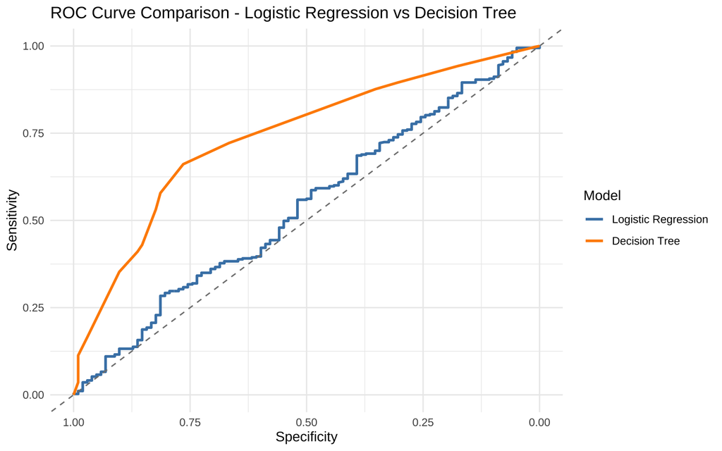

The decision tree did better, with an AUC of 0.740, an accuracy of 0.684, and a specificity of 0.765. Its variable importance plot shows that household income contributed the most to the splits, followed by poverty rate, college attainment, and unemployment rate. This suggests that the household income of the tract and the poverty rate carry a bit more signal than the other two features. The tree diagram gives a clearer picture of how the model actually makes decisions. Starting from the root, it first splits on household income, then works down through combinations of the four variables to classify each observation. This kind of threshold based structure is more intuitive to interpret than a set of regression coefficients.

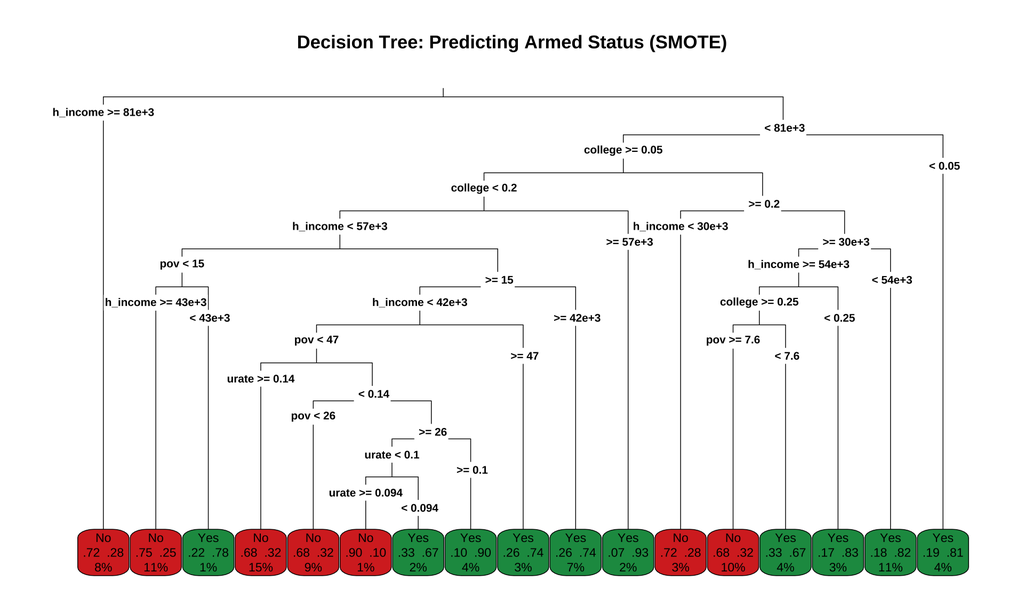

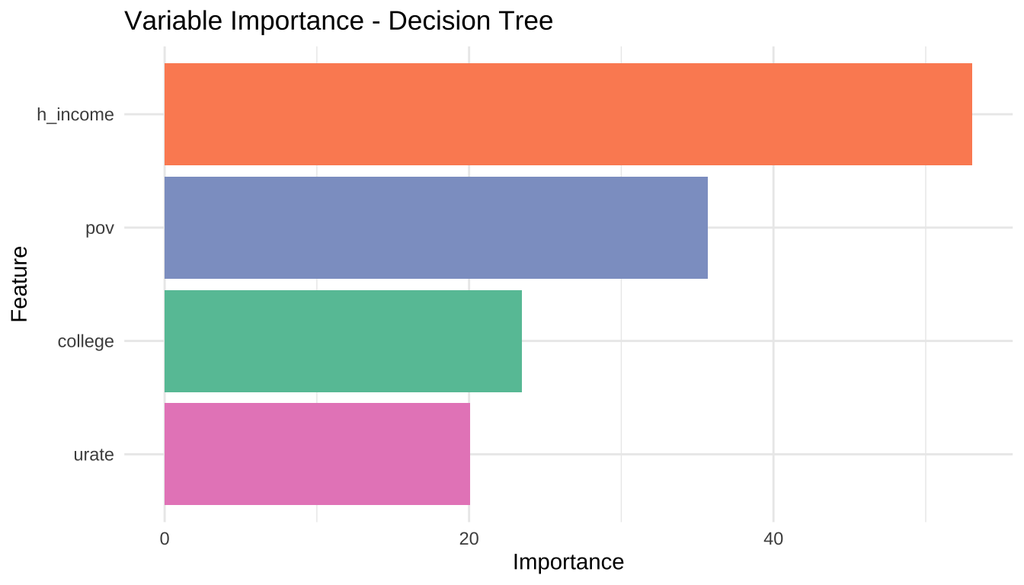

Comparing both models, the decision tree outperformed logistic regression by a reasonable margin. One likely reason for this is that logistic regression assumes a linear relationship between each predictor and the outcome. If the true relationship is non-linear, for example, if the poverty rate only starts to matter above a certain threshold, logistic regression will miss that. Overall, the decision tree is able to explain a meaningful portion of the variation in whether a victim is armed, and the table below summarizes the key metrics for both models. However, the results also suggest some limitations. While neighborhood socioeconomic features provide useful information, they may not fully capture individual level behavior. Incorporating more detailed personal or situational variables could further improve the model’s explanatory and predictive power.

| Model | Training_Data | Accuracy | Sensitivity | Specificity | AUC |
| --- | --- | --- | --- | --- | --- |
| Logistic Regression | SMOTE-balanced | 0.4839 | 0.4628 | 0.5588 | 0.5385 |
| Decision Tree | SMOTE-balanced | 0.6839 | 0.6612 | 0.7647 | 0.7401 |

### Question 2

Public discussions of algorithmic fairness in policing often focus on whether predictive systems explicitly use race as an input. A model that excludes race as a feature is sometimes described as “race-blind.” This framing assumes that non-racial features carry no racial information, but in practice, features such as neighborhood poverty, unemployment, and education are correlated with race through U.S. residential segregation and socioeconomic history. This project tests that assumption directly. The core question is whether we can predict a victim’s race (White, Black, or Hispanic/Latino) using only features that do not explicitly reference the racial makeup of the surrounding neighborhood. To put the answer in context, we also fit a full-information benchmark that adds the tract’s explicit racial composition. The benchmark is not a competing prediction task, because a model that knows a victim was killed in a 90 percent Black tract can trivially guess the victim is Black. Instead, it serves as an upper bound that quantifies how much of the total available racial signal a race-blind predictor can recover. The analysis is restricted to the three racial groups large enough to model reliably (White n = 235, Black n = 133, Hispanic/Latino n = 66) and uses 434 victims with complete covariates. Victims coded as “Unknown,” “Asian/Pacific Islander,” or “Native American” are excluded because there are too few observations in those categories for a three-way or broader classifier.

We constructed a ladder of four nested feature sets and compared three modeling algorithms on each. Feature set A contains only incident-level variables: victim age, gender, cause of death, and whether the victim was armed (collapsed into three categories: Firearm, Other weapon, or Unarmed). Feature set B contains only tract-level socioeconomic features: median household income, poverty rate, unemployment rate, and the share of adults with a college degree. Feature set C combines A and B, which is our primary race-blind predictor, representing what a classifier built on neighborhood features could achieve. Feature set D is our upper-bound benchmark and adds the three tract racial-composition variables on top of C. The share of the tract population that is non-Hispanic White (share_white), Black alone (share_black), and Hispanic/Latino of any race (share_hispanic). These three variables directly report the tract’s racial makeup, which is why we set D as a benchmark rather than a competing prediction. On each feature set we fit three models. A multinomial logistic regression is a classical statistical model for categorical outcomes with three or more classes that estimates the log-odds of each class as a weighted sum of the predictors. A random forest is an ensemble of 500 decision trees trained on random subsamples whose votes are averaged to produce a prediction and captures nonlinear feature interactions. A gradient boosting classifier is a second tree-ensemble method that builds trees sequentially so that each new tree corrects the errors of the previous ones. It is included as a sensitivity check to confirm our results do not depend on one specific algorithm. Performance was evaluated using five-fold cross-validation, a procedure in which the data are split into five chunks so every observation receives a prediction from a model that never saw it during training. We report two metrics: overall accuracy (the fraction of victims correctly classified, comparable to the majority-class baseline of 54.1 percent) and the macro-averaged Area Under the Receiver Operating Characteristic Curve (AUC). An AUC of 0.5 indicates chance performance and 1.0 indicates perfect classification. We define Model C as the race-blind classifier. It uses incident features (age, gender, cause of death, armed status) and tract socioeconomic features (household income, poverty rate, unemployment rate, college rate). No variable directly reports the tract’s racial makeup. Model D is defined as the upper-bound benchmark. Same as Model C, plus the three tract racial-composition variables (share_white, share_black, share_hispanic). To test whether the gap between Model C and the Model D benchmark was statistically significant, we used a paired bootstrap procedure with 2,000 resamples of the out-of-fold predictions.

**Figure 1: Accuracy and AUC across feature ladder**

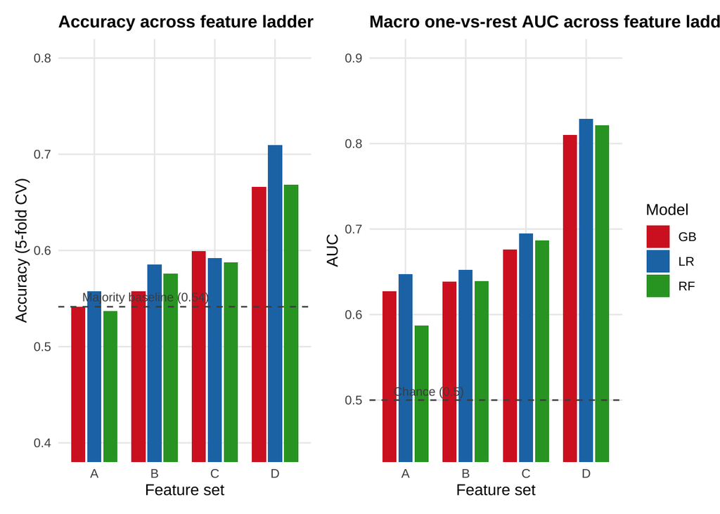

**Table 1:Cross-validated performance across feature sets and models**

Table 1. Cross-validated performance across feature sets and models.

| Feature set | LR accuracy | LR AUC | RF accuracy | RF AUC | GB accuracy | GB AUC |
| --- | --- | --- | --- | --- | --- | --- |
| [Majority-class baseline] | 0.541 | NA | NA | NA | NA | NA |
| A. Incident only | 0.558 | 0.648 | 0.537 | 0.587 | 0.541 | 0.627 |
| B. Tract SES only | 0.585 | 0.653 | 0.576 | 0.639 | 0.558 | 0.638 |
| C. Incident + SES | 0.592 | 0.695 | 0.588 | 0.687 | 0.599 | 0.676 |
| D. C + Tract racial mix | 0.710 | 0.829 | 0.668 | 0.821 | 0.666 | 0.810 |

**Figure 2**

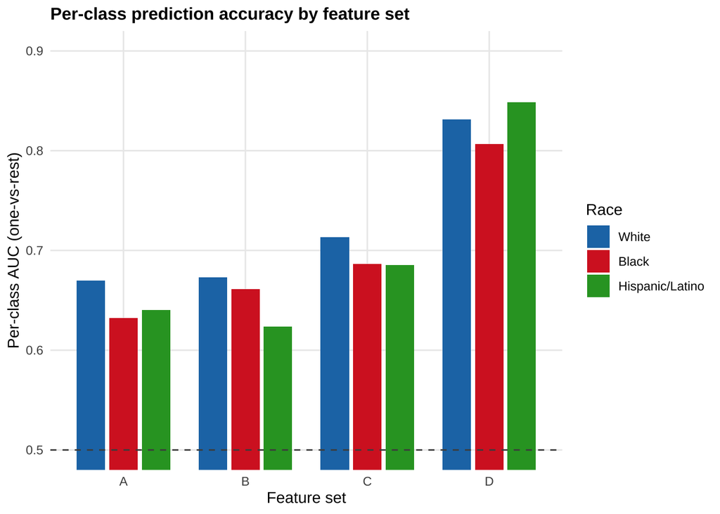

**Figure 3: Confusion matrices for Model C and D**

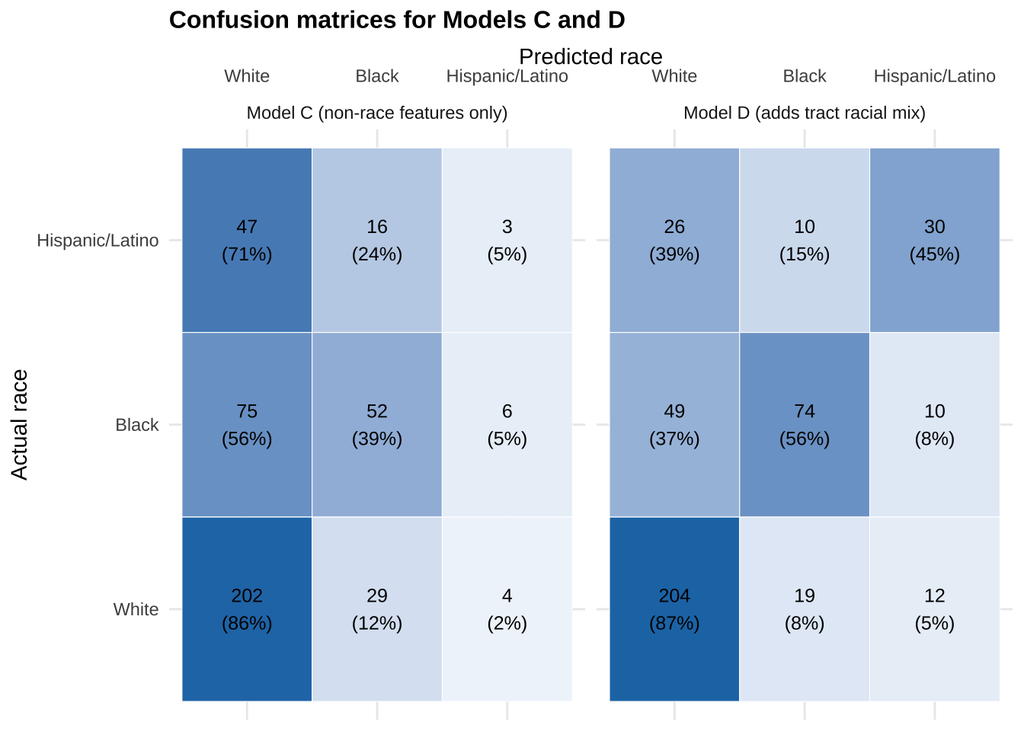

**Figure 4: Feature importance and standardized coefficients**

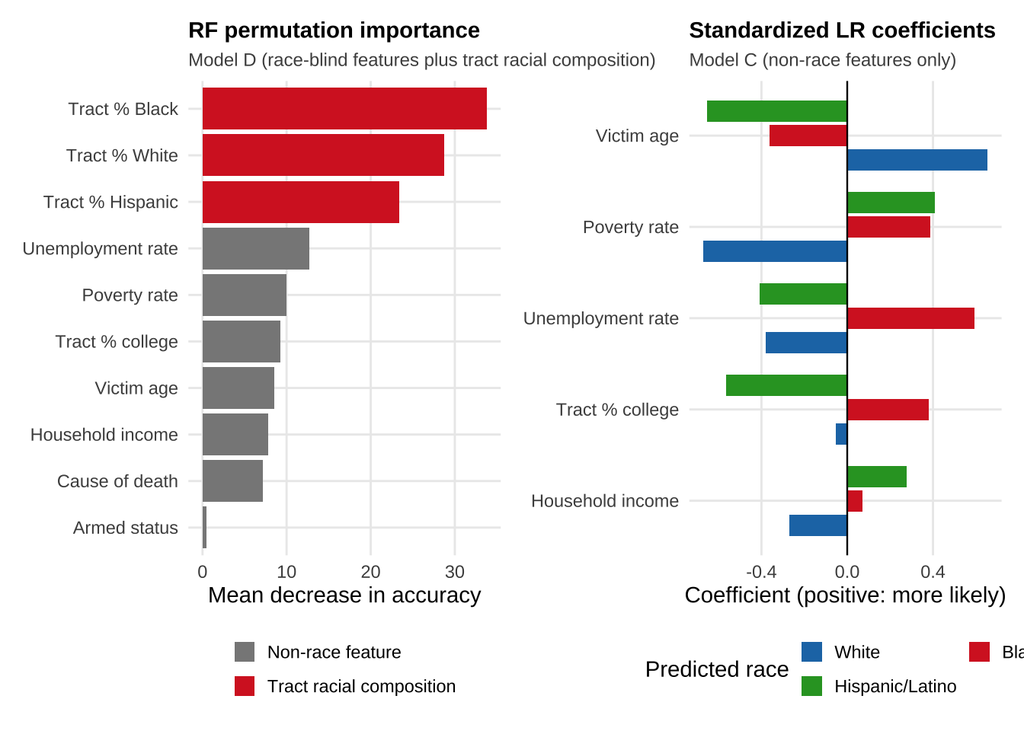

The race-blind classifier predicts the race of police-killing victims with accuracy well above the majority-class baseline (58.8 percent versus 54.1 percent) and with AUC 0.68 against a chance baseline of 0.50. Comparing this to the upper-bound benchmark that includes tract racial composition (AUC 0.83), the race-blind classifier recovers roughly 55 percent of the total available racial signal without ever seeing a variable that explicitly reports neighborhood race. The confusion-matrix analysis sharpens this conclusion by showing where the race-blind model falls short: it is essentially a Black-versus-White classifier and almost never actively predicts Hispanic victims. Together, these findings offer a concrete, quantified illustration of a well-known phenomenon in algorithmic fairness. In a country with substantial residential segregation, features such as age, poverty, unemployment, and education carry a meaningful amount of racial information, and a predictive model that excludes race as an input is not, in any meaningful operational sense, actually race-blind. The main limitations are that the dataset covers only the first half of 2015 and only fatal encounters, the three racial groups we analyze are the only ones with enough observations to model, and the definitions of the three share variables in the data are not mutually exclusive (share_white is non-Hispanic white, share_black is Black alone, and share_hispanic is Hispanic of any race), so they are best interpreted as standard Census measures of racial composition rather than a clean partition of the tract population.